# IMDB dataset

Cathy-Yuanmeng-Gu

## 0.1 Background

IMDb (Internet Movie Database) is an Amazon-owned online database of movie-related information. It contains data related to movies, television programmes, video games, and reviews.

## 0.2 Load the data

In the following, we will look at a subset sample of movies, taken from the [Kaggle IMDB 5000 movie dataset](https://www.kaggle.com/carolzhangdc/imdb-5000-movie-dataset)

```r
movies <- read_csv(here::here("data", "movies.csv"))

glimpse(movies)
```

[output not shown]

## 0.3 Inspect the data

First of all, we will take a look at the dataframe to determine if it contains duplicates or missing values to prepare for the following analyses.

```r
#Skim function provides a broad overview of the dataset
movies <- read_csv(here::here("data", "movies.csv"))
options(scipen = 999)
skim(movies) %>%
  knit_print()
```

Data summary

| Name | movies |
| --- | --- |
| Number of rows | 2961 |
| Number of columns | 11 |
| _______________________ |  |
| Column type frequency: |  |
| character | 3 |
| numeric | 8 |
| ________________________ |  |
| Group variables | None |

**Variable type: character**

| skim_variable | n_missing | complete_rate | min | max | empty | n_unique | whitespace |
| --- | --- | --- | --- | --- | --- | --- | --- |
| title | 0 | 1 | 1 | 83 | 0 | 2907 | 0 |
| genre | 0 | 1 | 5 | 11 | 0 | 17 | 0 |
| director | 0 | 1 | 3 | 32 | 0 | 1366 | 0 |

**Variable type: numeric**

| skim_variable | n_missing | complete_rate | mean | sd | p0 | p25 | p50 | p75 | p100 | hist |
| --- | --- | --- | --- | --- | --- | --- | --- | --- | --- | --- |
| year | 0 | 1 | 2002.90 | 9.95 | 1920.0 | 1999.0 | 2004.0 | 2010.0 | 2016.0 | ▁▁▁▂▇ |
| duration | 0 | 1 | 109.65 | 22.17 | 37.0 | 95.0 | 106.0 | 119.0 | 330.0 | ▃▇▁▁▁ |
| gross | 0 | 1 | 58090400.90 | 72469621.94 | 703.0 | 12276810.0 | 34703228.0 | 75590286.0 | 760505847.0 | ▇▁▁▁▁ |
| budget | 0 | 1 | 40619384.06 | 43682007.78 | 218.0 | 11000000.0 | 26000000.0 | 55000000.0 | 300000000.0 | ▇▂▁▁▁ |
| cast_facebook_likes | 0 | 1 | 12393.76 | 20530.11 | 0.0 | 2241.0 | 4604.0 | 16926.0 | 656730.0 | ▇▁▁▁▁ |
| votes | 0 | 1 | 109307.49 | 158143.91 | 5.0 | 19918.0 | 55749.0 | 133348.0 | 1689764.0 | ▇▁▁▁▁ |
| reviews | 0 | 1 | 503.31 | 493.74 | 2.0 | 199.0 | 364.0 | 631.0 | 5312.0 | ▇▁▁▁▁ |
| rating | 0 | 1 | 6.39 | 1.05 | 1.6 | 5.8 | 6.5 | 7.1 | 9.3 | ▁▁▆▇▁ |

```r
#duplicated function provides an overview of duplicated values
sum(duplicated(movies))
```

```
## [1] 0
```

> As seen above there are no missing values in the dataset. As the `sum(duplicated(movies))` function shows, the dataset does not include duplicated entries either.

> However, the skim overview shows that the data encompasses 2,961 rows and just 2,907 unique movie titles.

```r
#function shows number of duplicated movie tiles
sum(duplicated(movies$title))
```

```
## [1] 54
```

> The `sum(duplicated(movies$title))` data clearly shows that there are 54 duplicated movie titles. This number is exactly the difference between the total number of records (2,961) and the number of unique movie titles (2,907).

The following table gives an overview of all duplicated movie titles.

```r
movies %>%
  #filter for duplicated titles
  filter(duplicated(movies$title)) %>%
  #arrange movies by title in alphabetical order
  arrange(title) %>%
  #display a table with the duplicates
  kable(caption="Duplicated Movies", col.names=c("Movie Title", "Genre", "Director", "Year", "Duration", "Gross earnings", "Budget", "Facebook likes", "Votes", "Reviews", "Rating")) %>%
  #chose styling
  kable_material_dark() %>%
  #make table scrollable
  kableExtra::scroll_box(height = "500px")
```

Duplicated Movies

| Movie Title | Genre | Director | Year | Duration | Gross earnings | Budget | Facebook likes | Votes | Reviews | Rating |
| --- | --- | --- | --- | --- | --- | --- | --- | --- | --- | --- |
| A Nightmare on Elm Street | Horror | Wes Craven | 1984 | 101 | 26505000 | 1800000 | 42918 | 149293 | 924 | 7.5 |
| Across the Universe | Drama | Julie Taymor | 2007 | 133 | 24343673 | 45000000 | 5405 | 91863 | 680 | 7.4 |
| Alice in Wonderland | Adventure | Tim Burton | 2010 | 108 | 334185206 | 200000000 | 79957 | 306336 | 1187 | 6.5 |
| Aloha | Comedy | Cameron Crowe | 2015 | 105 | 20991497 | 37000000 | 44037 | 39782 | 310 | 5.4 |
| Around the World in 80 Days | Action | Frank Coraci | 2004 | 120 | 24004159 | 110000000 | 3175 | 68722 | 379 | 5.8 |
| Brothers | Drama | Jim Sheridan | 2009 | 105 | 28501651 | 26000000 | 39473 | 88037 | 418 | 7.1 |
| Carrie | Drama | Kimberly Peirce | 2013 | 100 | 35266619 | 30000000 | 20051 | 108248 | 730 | 5.9 |
| Chasing Liberty | Comedy | Andy Cadiff | 2004 | 101 | 12189514 | 23000000 | 829 | 30092 | 194 | 6.1 |
| Cinderella | Drama | Kenneth Branagh | 2015 | 105 | 201148159 | 95000000 | 4671 | 103749 | 666 | 7.0 |
| Clash of the Titans | Action | Louis Leterrier | 2010 | 106 | 163192114 | 125000000 | 18003 | 229687 | 981 | 5.8 |
| Conan the Barbarian | Adventure | John Milius | 1982 | 129 | 37567440 | 20000000 | 2024 | 113068 | 503 | 6.9 |
| Dawn of the Dead | Action | Zack Snyder | 2004 | 110 | 58885635 | 26000000 | 10438 | 194426 | 1344 | 7.4 |
| Disturbia | Drama | D.J. Caruso | 2007 | 105 | 80050171 | 20000000 | 2287 | 186984 | 744 | 6.9 |
| Dodgeball: A True Underdog Story | Comedy | Rawson Marshall Thurber | 2004 | 92 | 114324072 | 20000000 | 4730 | 185345 | 583 | 6.7 |
| Ghostbusters | Action | Paul Feig | 2016 | 116 | 118099659 | 144000000 | 2097 | 69790 | 1675 | 5.5 |
| Glory | Drama | Edward Zwick | 1989 | 122 | 26830000 | 18000000 | 32930 | 101889 | 425 | 7.9 |
| Goosebumps | Adventure | Rob Letterman | 2015 | 103 | 80021740 | 58000000 | 5497 | 47988 | 372 | 6.4 |
| Halloween | Horror | John Carpenter | 1978 | 101 | 47000000 | 300000 | 4400 | 157863 | 1509 | 7.9 |
| Home | Adventure | Tim Johnson | 2015 | 94 | 177343675 | 135000000 | 17883 | 70133 | 379 | 6.7 |
| Home | Adventure | Tim Johnson | 2015 | 94 | 177343675 | 135000000 | 17883 | 70136 | 379 | 6.7 |
| Jack Reacher | Action | Christopher McQuarrie | 2012 | 130 | 80033643 | 60000000 | 16385 | 226583 | 835 | 7.0 |
| Juno | Comedy | Jason Reitman | 2007 | 96 | 143492840 | 7500000 | 28817 | 414345 | 1268 | 7.5 |
| Mercury Rising | Action | Harold Becker | 1998 | 111 | 32940507 | 60000000 | 16536 | 54314 | 206 | 6.1 |
| Murder by Numbers | Crime | Barbet Schroeder | 2002 | 115 | 31874869 | 50000000 | 34605 | 43575 | 438 | 6.1 |
| Oz the Great and Powerful | Adventure | Sam Raimi | 2013 | 130 | 234903076 | 215000000 | 73441 | 175413 | 1036 | 6.4 |
| Pan | Adventure | Joe Wright | 2015 | 111 | 34964818 | 150000000 | 21393 | 39956 | 442 | 5.8 |
| Planet of the Apes | Action | Tim Burton | 2001 | 119 | 180011740 | 100000000 | 2776 | 177729 | 1598 | 5.7 |
| Point Break | Action | Ericson Core | 2015 | 114 | 28772222 | 105000000 | 3962 | 33958 | 326 | 5.3 |
| Poltergeist | Fantasy | Tobe Hooper | 1982 | 120 | 76600000 | 10700000 | 3876 | 105448 | 544 | 7.4 |
| Precious | Drama | Lee Daniels | 2009 | 109 | 47536959 | 10000000 | 3276 | 86956 | 598 | 7.3 |
| RoboCop | Action | Jose Padilha | 2014 | 117 | 58607007 | 100000000 | 14160 | 182910 | 1122 | 6.2 |
| Sabotage | Action | David Ayer | 2014 | 109 | 10499968 | 35000000 | 1458 | 47502 | 445 | 5.7 |
| Side Effects | Crime | Steven Soderbergh | 2013 | 106 | 32154410 | 30000000 | 18469 | 148334 | 724 | 7.1 |
| Snitch | Action | Ric Roman Waugh | 2013 | 112 | 42919096 | 15000000 | 15800 | 64748 | 360 | 6.5 |
| Spider-Man 3 | Action | Sam Raimi | 2007 | 156 | 336530303 | 258000000 | 46055 | 383071 | 2294 | 6.2 |
| Syriana | Drama | Stephen Gaghan | 2005 | 128 | 50815288 | 50000000 | 14747 | 109191 | 983 | 7.0 |
| Teenage Mutant Ninja Turtles | Action | Jonathan Liebesman | 2014 | 101 | 190871240 | 125000000 | 2690 | 167089 | 839 | 5.9 |
| The Astronaut’s Wife | Drama | Rand Ravich | 1999 | 109 | 10654581 | 34000000 | 52621 | 45500 | 367 | 5.3 |
| The Day the Earth Stood Still | Drama | Scott Derrickson | 2008 | 104 | 79363785 | 80000000 | 22194 | 139426 | 974 | 5.5 |
| The Fast and the Furious | Action | Rob Cohen | 2001 | 106 | 144512310 | 38000000 | 45327 | 272227 | 1175 | 6.7 |
| The Fog | Fantasy | John Carpenter | 1980 | 89 | 21378000 | 1000000 | 4877 | 46492 | 547 | 6.8 |
| The Gambler | Crime | Rupert Wyatt | 2014 | 111 | 33631221 | 25000000 | 3784 | 48562 | 320 | 6.0 |
| The Gift | Mystery | Joel Edgerton | 2015 | 108 | 43771291 | 5000000 | 3215 | 79916 | 576 | 7.1 |
| The Island | Action | Michael Bay | 2005 | 136 | 35799026 | 126000000 | 34838 | 263336 | 1156 | 6.9 |
| The Karate Kid | Action | John G. Avildsen | 1984 | 126 | 90800000 | 8000000 | 2004 | 126916 | 316 | 7.2 |
| The Last House on the Left | Crime | Dennis Iliadis | 2009 | 114 | 32721635 | 15000000 | 3861 | 67824 | 520 | 6.6 |
| The Lovely Bones | Drama | Peter Jackson | 2009 | 135 | 43982842 | 65000000 | 2369 | 125114 | 901 | 6.7 |
| The Texas Chain Saw Massacre | Horror | Tobe Hooper | 1974 | 88 | 30859000 | 83532 | 1094 | 96411 | 1103 | 7.5 |
| The Tourist | Action | Florian Henckel von Donnersmarck | 2010 | 103 | 67631157 | 100000000 | 55175 | 176606 | 695 | 6.0 |
| The Unborn | Drama | David S. Goyer | 2009 | 89 | 42638165 | 16000000 | 12183 | 42183 | 408 | 4.8 |
| The Watch | Action | Akiva Schaffer | 2012 | 102 | 34350553 | 68000000 | 2486 | 104072 | 472 | 5.7 |
| TRON: Legacy | Action | Joseph Kosinski | 2010 | 125 | 172051787 | 170000000 | 25549 | 264186 | 1134 | 6.8 |
| Twilight | Drama | Catherine Hardwicke | 2008 | 122 | 191449475 | 37000000 | 44060 | 348007 | 1885 | 5.2 |
| Victor Frankenstein | Drama | Paul McGuigan | 2015 | 110 | 5773519 | 40000000 | 12876 | 28621 | 250 | 6.0 |

> As seen on the table above there are 54 duplicates. For the following analyses we will create a new dataset containing only unique / distinct movie titles.

```r
# Dataframe with only distinct movies
distinct_movies <- movies %>%

  # only keep unique movies
  distinct(title, genre, director, year, .keep_all = TRUE)
```

The following table displays the number of entries in our previously defined dataset.

```r
distinct_movies %>%
  #count distinct movies
  summarise(`number of distinct movies:` = n()) %>%
  #table
  kable(caption = "Distinct Movies") %>%
  #chose styling
  kable_material_dark()
```

Distinct Movies

| number of distinct movies: |
| --- |
| 2907 |

> Our new dataframe now includes 2,907 distinct movies, thus matching the number of unique titles from the `skimr::skim(movies)` overview.

## 0.4 Analyze the data

Now we can start our analyses by taking a look at the count of movies by genre, ranked in descending order.

```r
distinct_movies %>%
  #group movies by genre
  group_by(genre) %>%
  #count number of movies per genre
  summarise(`number of movies` = n()) %>%
  #arrange genres in descending order of number of movies
  arrange(desc(`number of movies`)) %>%
  #table
  kable(caption = "Movies by genre") %>%
  #chose styling
   kable_material_dark() %>%
  #make table scrollable
  kableExtra::scroll_box(height = "500px")
```

Movies by genre

| genre | number of movies |
| --- | --- |
| Comedy | 844 |
| Action | 719 |
| Drama | 484 |
| Adventure | 281 |
| Crime | 198 |
| Biography | 135 |
| Horror | 128 |
| Animation | 35 |
| Fantasy | 26 |
| Documentary | 25 |
| Mystery | 15 |
| Sci-Fi | 7 |
| Family | 3 |
| Musical | 2 |
| Romance | 2 |
| Western | 2 |
| Thriller | 1 |

Next, we will take a closer look at our data by producing a table containing the average gross earnings and budget by genre. For that purpose, we Calculate a variable `return_on_budget` which shows how many $ did a movie make at the box office for each $ of its budget and rank the genres by this variable in descending order.

```r
distinct_movies %>%
  #group movies by genre
  group_by(genre) %>%
  #calculate average values in millions and define single data points per genre
  summarize(avg_gross = mean(gross)/1000000,
            avg_budget= mean(budget)/1000000) %>%
  #add and calculate return_on_budget
  mutate(return_on_budget = 100* (avg_gross - avg_budget) / avg_budget) %>%
  #arrange by return on budget in descending order
  arrange(desc(return_on_budget)) %>%
  #add titles to the table and columns
  kable(position="center", caption="Average USD gross earnings, budget and return on budget per genre", col.names=c("Genre", "Average gross earnings(m)", "Average budget(m)", "Return on budget(%)")) %>%
  #chose styling
  kable_material_dark() %>%
  #make table scrollable
  kableExtra::scroll_box(height = "500px")
```

Average USD gross earnings, budget and return on budget per genre

| Genre | Average gross earnings(m) | Average budget(m) | Return on budget(%) |
| --- | --- | --- | --- |
| Musical | 92.084 | 3.19 | 2787.1 |
| Family | 149.160 | 14.83 | 905.6 |
| Western | 20.822 | 3.46 | 500.9 |
| Documentary | 17.354 | 5.89 | 194.7 |
| Horror | 37.782 | 13.80 | 173.7 |
| Fantasy | 41.903 | 18.48 | 126.7 |
| Comedy | 42.488 | 24.46 | 73.7 |
| Mystery | 69.117 | 41.50 | 66.5 |
| Animation | 98.434 | 61.70 | 59.5 |
| Biography | 45.202 | 28.54 | 58.4 |
| Adventure | 94.350 | 64.69 | 45.8 |
| Drama | 36.755 | 25.83 | 42.3 |
| Crime | 37.602 | 26.53 | 41.7 |
| Romance | 31.265 | 25.11 | 24.5 |
| Action | 86.270 | 70.78 | 21.9 |
| Sci-Fi | 29.788 | 27.61 | 7.9 |
| Thriller | 0.002 | 0.30 | -99.2 |

To make further sense of our data, we will produce a table that shows the top 15 directors who have created the highest gross revenue in the box office and include the total gross amount, mean, median, and standard deviation per director.

```r
distinct_movies %>%
  #group movies by director
  group_by(director) %>%
  #calculate total gross revenues, mean, median, and standard deviation and summarize them per director
  summarize(sum_gross=sum(gross)/1000000,
            mean = mean(gross)/1000000,
            median = median(gross)/1000000,
            sd = sd(gross)/1000000 ) %>%
  #arrange movies by total gross revenues in descending order
  arrange(desc(sum_gross)) %>%
  #only display the top 15 directors
  head(15) %>%
  #add titles to the table and columns
  kable(caption="Top 15 directors by box office gross revenues in USD", col.names=c("Director", "Total gross revenues(m)", "Mean(m)", "Median(m)", "SD(m)")) %>%
  #chose styling
  kable_material_dark() %>%
  #make table scrollable
  kableExtra::scroll_box(height = "500px")
```

Top 15 directors by box office gross revenues in USD

| Director | Total gross revenues(m) | Mean(m) | Median(m) | SD(m) |
| --- | --- | --- | --- | --- |
| Steven Spielberg | 4014 | 174.5 | 164.4 | 101.4 |
| Michael Bay | 2195 | 183.0 | 168.5 | 125.8 |
| James Cameron | 1910 | 318.3 | 175.6 | 309.2 |
| Christopher Nolan | 1813 | 226.7 | 196.7 | 187.2 |
| George Lucas | 1741 | 348.3 | 380.3 | 146.2 |
| Robert Zemeckis | 1619 | 124.6 | 100.9 | 91.3 |
| Tim Burton | 1557 | 111.2 | 69.8 | 99.3 |
| Sam Raimi | 1443 | 180.4 | 138.5 | 174.7 |
| Clint Eastwood | 1378 | 72.5 | 46.7 | 75.5 |
| Francis Lawrence | 1359 | 271.7 | 281.7 | 135.4 |
| Ron Howard | 1336 | 111.3 | 101.6 | 81.9 |
| Gore Verbinski | 1330 | 189.9 | 123.2 | 154.5 |
| Andrew Adamson | 1137 | 284.4 | 279.7 | 120.9 |
| Shawn Levy | 1130 | 102.7 | 85.5 | 65.5 |
| Ridley Scott | 1129 | 80.6 | 47.8 | 68.8 |

## 0.5 Visualize the data

Finally, we look at movie ratings and produce a table that describes how ratings are distributed by genre. We use a histogram to visualize how ratings are distributed.

```r
distinct_movies %>%
  #group movies by genre
  group_by(genre) %>%
  #summarize mean, min, max, sd of ratings per genre
  summarize(mean= mean(rating),
            min=min(rating),
            max=max(rating),
            sd=sd(rating)) %>%
  #arrange in descending order
  arrange(desc(mean)) %>%
  #add titles to the table and columns
  kable(caption="Distribution of ratings by genre", col.names = c("Genre", "Mean", "Min", "Max", "SD")) %>%
  #chose styling
  kable_material_dark() %>%
    #make table scrollable
   kableExtra::scroll_box(height = "500px")
```

Distribution of ratings by genre

| Genre | Mean | Min | Max | SD |
| --- | --- | --- | --- | --- |
| Biography | 7.11 | 4.5 | 8.9 | 0.760 |
| Crime | 6.92 | 4.8 | 9.3 | 0.853 |
| Mystery | 6.84 | 4.6 | 8.5 | 0.910 |
| Musical | 6.75 | 6.3 | 7.2 | 0.636 |
| Drama | 6.74 | 2.1 | 8.8 | 0.915 |
| Documentary | 6.66 | 1.6 | 8.5 | 1.767 |
| Sci-Fi | 6.66 | 5.0 | 8.2 | 1.094 |
| Animation | 6.65 | 4.5 | 8.0 | 0.968 |
| Romance | 6.65 | 6.2 | 7.1 | 0.636 |
| Adventure | 6.51 | 2.3 | 8.6 | 1.106 |
| Family | 6.50 | 5.7 | 7.9 | 1.217 |
| Action | 6.23 | 2.1 | 9.0 | 1.039 |
| Comedy | 6.11 | 1.9 | 8.8 | 1.024 |
| Fantasy | 6.08 | 4.3 | 7.9 | 0.953 |
| Horror | 5.79 | 3.6 | 8.5 | 0.987 |
| Western | 5.70 | 4.1 | 7.3 | 2.263 |
| Thriller | 4.80 | 4.8 | 4.8 | NA |

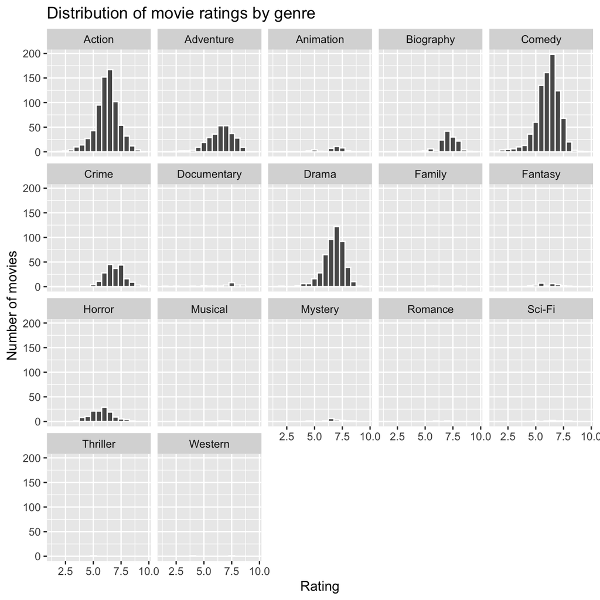

```r
opts_chunk$set(echo=FALSE)
 #plot histogram
 distinct_movies %>%
  ggplot(data = distinct_movies, mapping = aes(x = rating) ) +
  #add white bin lines
      geom_histogram(color = "White", binwidth = 0.5) +
  #add titles to the plot and axes
      labs(title="Distribution of movie ratings by genre", x="Rating", y="Number of movies") +
  #wrap by genre
  facet_wrap(~genre)
```

```r
  #choose theme
      theme_gray()
```

[output not shown]

[output cut: 360 more lines]

[output not shown]

In order to make further sense of our data we will now examine the relationship between gross revenues and facebook likes the cast of each movie receives by way of a scatterplot. This analysis will allow us to determine if the number of facebook likes a cast has received is an indicator of the money a movie will make at the box office.

[figure not shown]

> The analysis shows that there is no correlation at all between the number of facebook likes a cast receives and the gross box office revenues a movie makes.

> However, there maybe other variables that may indicate a movie’s financial success at the box office. The next variable we will analyze is a movie’s budget, i.e. the budget’s relationship to a movie’s box office revenues.

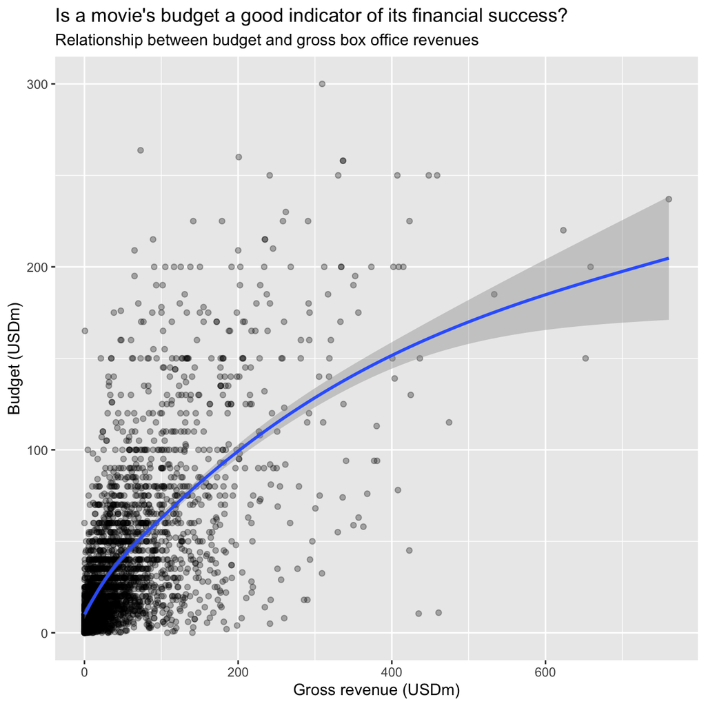

> The plot clearly displays a positive correlation between a movie’s budget and the gross box office revenues it makes, thus qualifying a movie’s budget as a good indicator of its financial success. This relationship is particularly intuitive since movies with a higher budget i.e. higher expenses must generate higher revenues on order to be profitable. Beyond that, if a movie has a high budget the spending on marketing as well as the overall quality of production may be higher, thus attracting more viewers.

To end our analyses we will determine how the relationship between a movie’s box office revenues and its rating varies by genre.

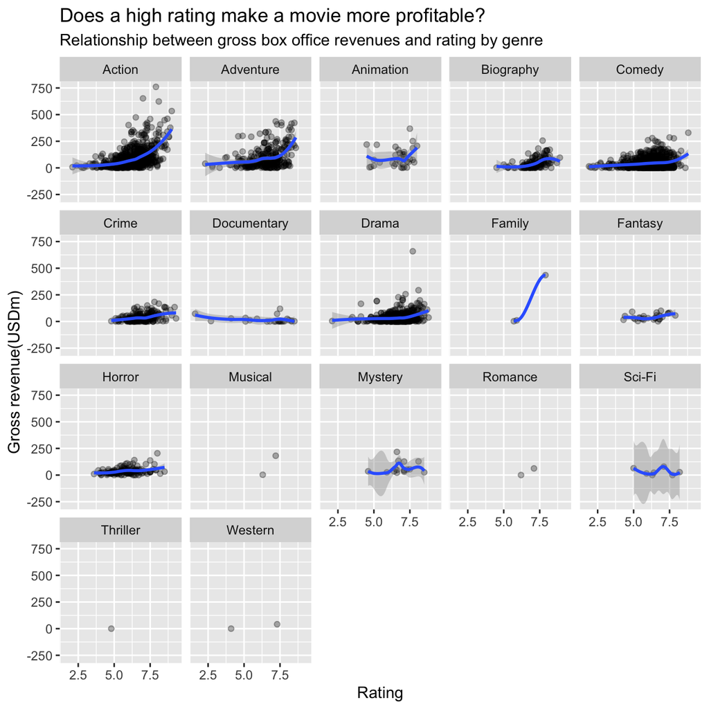